# CS7324 - Lab 3: Extending Logistic Regression

### Zach Bohl and Luigi Allen

Airline Passenger Satisfation Dataset: https://www.kaggle.com/datasets/teejmahal20/airline-passenger-satisfaction

## Preparation and Overview

1. **Flight Distance:** Longer flights might have a higher proportion of Business and Economy Plus passengers.
2. **In-flight Services:** Ratings for Wi-Fi, entertainment, and seat comfort can indicate the class, as Business class typically offers superior services.
3. **Baggage Handling:** Satisfaction with baggage handling might correlate with higher travel classes.
4. **Customer Satisfaction:** Overall satisfaction scores can be higher for Business and Economy Plus passengers.
5. **Flight Delays:** Passengers in higher classes might experience fewer delays or have different perceptions of delays.
6. **Age:** Different age groups might prefer different travel classes.
7. **Gender:** There might be trends in travel class preferences based on gender.
8. **Type of Traveler:** Business travelers are more likely to be in Business class, while leisure travelers might prefer Economy or Economy Plus.

### Business Use-Case:

The goal of predicting travel class can provide insights into passenger behavior and help airlines such as American Airlines (AA) to optimize their service offerings and revenue management strategies. Airlines could use this information for:

- **Revenue Optimization:** Understanding the factors that influence travel class choices allows airlines to adjust pricing, promotions, and services to encourage passengers to upgrade to higher classes (e.g., from Economy to Economy Plus or Business).
- **Passenger Segmentation:** Airlines can use this model to tailor services to specific passenger segments, such as offering personalized upgrades or add-on services to Economy Plus passengers likely to switch to Business class. Currently, American Airlines does not offer upgrades to their lowest tier(Economy) customers to switch to top tier(Buisness class).
- **Operational Efficiency:** The model can help forecast the demand for each travel class on specific routes, allowing airlines to adjust flight capacity by switch to larger aircraft (e.g., assigning aircraft that has more Business class seats for the most popular routes).

### Interested Parties:

The parties at American Airlines that would be interested in the results are as follows:

- **Revenue Management Teams:** They can use the model to identify passengers more likely to purchase upgrades or additional services, optimizing pricing strategies for different classes.
- **Customer Experience Teams:** Understanding class preferences allows these teams to tailor in-flight experiences, loyalty rewards, and offers based on predicted class choice.
- **Airline Executives:** Senior leadership can make data-driven decisions regarding fleet configuration (e.g., more Business class seats on high-demand routes).
- **Marketing Teams:** These teams can leverage insights to create targeted promotions and campaigns for each class of traveler, improving customer acquisition and retention.

### Deployed Model:

The model will be deployed in the booking system to predict and offer real-time travel class upgrades or special offers for passengers who are likely to switch from Economy to Economy Plus or Business.

### Performance Requirements:

To be valuable for real-time deployment or offline analysis, the model should ideally achieve at least 80% accuracy or higher. However, since American Airlines make significant revenue from upgrades, improving the precision and recall for Business class predictions may be crucial. Airlines would aim for high recall (e.g., >90%) in identifying potential Business class passengers, as a missed opportunity here could directly impact revenue.

The classifier's performance could also be evaluated using F1-score, particularly for underrepresented classes (e.g., Economy Plus, which might have fewer passengers than Economy).

```python
import pandas as pd

df1 = pd.read_csv('archive/train.csv')
df2 = pd.read_csv('archive/test.csv')

df = pd.concat([df1, df2], ignore_index=True)
```

Next, we concatenate both the training and testing DataFrames into a single DataFrame, df, using pd.concat(). This is a crucial step because it allows us to apply uniform preprocessing and transformations across the entire dataset. By doing this, we ensure consistency, as the same transformations are applied to both the training and testing data. This also helps avoid redundancy in the preprocessing steps, making our workflow more streamlined.

```python
df.head()
```

|  | Unnamed: 0 | id | Gender | Customer Type | Age | Type of Travel | Class | Flight Distance | Inflight wifi service | Departure/Arrival time convenient | ... | Inflight entertainment | On-board service | Leg room service | Baggage handling | Checkin service | Inflight service | Cleanliness | Departure Delay in Minutes | Arrival Delay in Minutes | satisfaction |
| --- | --- | --- | --- | --- | --- | --- | --- | --- | --- | --- | --- | --- | --- | --- | --- | --- | --- | --- | --- | --- | --- |
| 0 | 0 | 70172 | Male | Loyal Customer | 13 | Personal Travel | Eco Plus | 460 | 3 | 4 | ... | 5 | 4 | 3 | 4 | 4 | 5 | 5 | 25 | 18.0 | neutral or dissatisfied |
| 1 | 1 | 5047 | Male | disloyal Customer | 25 | Business travel | Business | 235 | 3 | 2 | ... | 1 | 1 | 5 | 3 | 1 | 4 | 1 | 1 | 6.0 | neutral or dissatisfied |
| 2 | 2 | 110028 | Female | Loyal Customer | 26 | Business travel | Business | 1142 | 2 | 2 | ... | 5 | 4 | 3 | 4 | 4 | 4 | 5 | 0 | 0.0 | satisfied |
| 3 | 3 | 24026 | Female | Loyal Customer | 25 | Business travel | Business | 562 | 2 | 5 | ... | 2 | 2 | 5 | 3 | 1 | 4 | 2 | 11 | 9.0 | neutral or dissatisfied |
| 4 | 4 | 119299 | Male | Loyal Customer | 61 | Business travel | Business | 214 | 3 | 3 | ... | 3 | 3 | 4 | 4 | 3 | 3 | 3 | 0 | 0.0 | satisfied |

5 rows × 25 columns

```python
categories = df.columns.tolist()

for category in categories:
    print(category)
```

```
Unnamed: 0
id
Gender
Customer Type
Age
Type of Travel
Class
Flight Distance
Inflight wifi service
Departure/Arrival time convenient
Ease of Online booking
Gate location
Food and drink
Online boarding
Seat comfort
Inflight entertainment
On-board service
Leg room service
Baggage handling
Checkin service
Inflight service
Cleanliness
Departure Delay in Minutes
Arrival Delay in Minutes
satisfaction
```

```python
df = df.drop(columns=['id', 'Unnamed: 0'])
```

In this preprocessing step we are dropping the id and Unnamed: 0 columns in order to clean the dataset and remove irrelevant or redundant information. This helps in simplifying the dataset, reducing noise, and improving the performance of subsequent analysis and modeling tasks.

```python
df['Gender'] = df['Gender'].map({'Male':1, 'Female': 0})
df['Customer Type'] = df['Customer Type'].map({'Loyal Customer': 1, 'disloyal Customer': 0})

age_bins = [0, 17, 35, 64, float('inf')]
age_labels = ['Juvenile', 'Young Adult', 'Adult', 'Elderly']

# Create a new column 'Age Group' with the categorical age groups
df['Age Group'] = pd.cut(df['Age'], bins=age_bins, labels=age_labels, right=True, include_lowest=True)

# One-hot encode the 'Age Group' column
df = pd.get_dummies(df, columns=['Age Group'])
```

Gender and Customer Type: By converting categorical variables into numerical format using label encoding, we make the data compatible with machine learning algorithms, simplify the dataset, and potentially improve the performance of our models. This preprocessing step is essential for preparing the data for analysis and modeling.

We choose to categorize ages into groups in order to simplify the analysis by reducing the number of unique values. This will be particularly useful for our visualizations and statistical summaries. Age groups are often more interpretable than raw age values. For example, understanding that a certain behavior is more common among 'Young Adults' is more intuitive than knowing it is common among people aged 18-24. This can help us in capturing more relevant patterns in the data.

One-Hot Encoding: We also converted the Age Group categorical variable into multiple binary columns, ensuring compatibility with machine learning algorithms and avoiding ordinal relationships.

```python
df = df.drop(columns=['Age'])
df.head()
```

|  | Gender | Customer Type | Type of Travel | Class | Flight Distance | Inflight wifi service | Departure/Arrival time convenient | Ease of Online booking | Gate location | Food and drink | ... | Checkin service | Inflight service | Cleanliness | Departure Delay in Minutes | Arrival Delay in Minutes | satisfaction | Age Group_Juvenile | Age Group_Young Adult | Age Group_Adult | Age Group_Elderly |
| --- | --- | --- | --- | --- | --- | --- | --- | --- | --- | --- | --- | --- | --- | --- | --- | --- | --- | --- | --- | --- | --- |
| 0 | 1 | 1 | Personal Travel | Eco Plus | 460 | 3 | 4 | 3 | 1 | 5 | ... | 4 | 5 | 5 | 25 | 18.0 | neutral or dissatisfied | 1 | 0 | 0 | 0 |
| 1 | 1 | 0 | Business travel | Business | 235 | 3 | 2 | 3 | 3 | 1 | ... | 1 | 4 | 1 | 1 | 6.0 | neutral or dissatisfied | 0 | 1 | 0 | 0 |
| 2 | 0 | 1 | Business travel | Business | 1142 | 2 | 2 | 2 | 2 | 5 | ... | 4 | 4 | 5 | 0 | 0.0 | satisfied | 0 | 1 | 0 | 0 |
| 3 | 0 | 1 | Business travel | Business | 562 | 2 | 5 | 5 | 5 | 2 | ... | 1 | 4 | 2 | 11 | 9.0 | neutral or dissatisfied | 0 | 1 | 0 | 0 |
| 4 | 1 | 1 | Business travel | Business | 214 | 3 | 3 | 3 | 3 | 4 | ... | 3 | 3 | 3 | 0 | 0.0 | satisfied | 0 | 0 | 1 | 0 |

5 rows × 26 columns

Dropping the Age column after categorizing it into age groups and one-hot encoding these groups in order to simplify the dataset, avoid redundancy, and focus the analysis on the categorical representation of age. This ensures that the dataset is clean and ready for further analysis and modeling.

```python
df['Type of Travel'].unique()
```

```
array(['Personal Travel', 'Business travel'], dtype=object)
```

```python
travel_type_mapping = {
    'Personal Travel': 0,
    'Business travel': 1
    # Add any other variations if necessary
}

# Map the 'Type of Travel' column
df['Type of Travel'] = df['Type of Travel'].map(travel_type_mapping)
```

```python
df['Class'].unique()
```

```
array(['Eco Plus', 'Business', 'Eco'], dtype=object)
```

```python
class_mapping = {
    'Eco': 1,
    'Eco Plus': 2,
    'Business': 3
    # Add any other variations if necessary
}

# Map the 'Class' column
df['Class'] = df['Class'].map(class_mapping)
```

```python
# Normalize the 'Flight Distance' column
min_distance = df['Flight Distance'].min()
max_distance = df['Flight Distance'].max()

# Handle cases where max_distance equals min_distance
if max_distance - min_distance != 0:
    df['Flight Distance'] = (df['Flight Distance'] - min_distance) / (max_distance - min_distance)
else:
    df['Flight Distance'] = 0.0  # All distances are the same
```

```python
# Convert to numeric and handle non-numeric entries
df['Departure Delay in Minutes'] = pd.to_numeric(df['Departure Delay in Minutes'], errors='coerce')

# Handle missing values
df['Departure Delay in Minutes'] = df['Departure Delay in Minutes'].fillna(0)

# Perform min-max normalization
min_departure_delay = df['Departure Delay in Minutes'].min()
max_departure_delay = df['Departure Delay in Minutes'].max()

if max_departure_delay - min_departure_delay != 0:
    df['Departure Delay in Minutes'] = (df['Departure Delay in Minutes'] - min_departure_delay) / (max_departure_delay - min_departure_delay)
else:
    df['Departure Delay in Minutes'] = 0.0  # All values are the same
```

```python
# Convert to numeric and handle non-numeric entries
df['Arrival Delay in Minutes'] = pd.to_numeric(df['Arrival Delay in Minutes'], errors='coerce')

# Handle missing values
df['Arrival Delay in Minutes'] = df['Arrival Delay in Minutes'].fillna(0)

# Perform min-max normalization
min_arrival_delay = df['Arrival Delay in Minutes'].min()
max_arrival_delay = df['Arrival Delay in Minutes'].max()

if max_arrival_delay - min_arrival_delay != 0:
    df['Arrival Delay in Minutes'] = (df['Arrival Delay in Minutes'] - min_arrival_delay) / (max_arrival_delay - min_arrival_delay)
else:
    df['Arrival Delay in Minutes'] = 0.0  # All values are the same
```

```python
satisfaction_mapping = {
    'satisfied': 1,
    'neutral or dissatisfied': 0
    # Add other variations if necessary
}

df['satisfaction'] = df['satisfaction'].map(satisfaction_mapping)
```

```python
df.head()
```

|  | Gender | Customer Type | Type of Travel | Class | Flight Distance | Inflight wifi service | Departure/Arrival time convenient | Ease of Online booking | Gate location | Food and drink | ... | Checkin service | Inflight service | Cleanliness | Departure Delay in Minutes | Arrival Delay in Minutes | satisfaction | Age Group_Juvenile | Age Group_Young Adult | Age Group_Adult | Age Group_Elderly |
| --- | --- | --- | --- | --- | --- | --- | --- | --- | --- | --- | --- | --- | --- | --- | --- | --- | --- | --- | --- | --- | --- |
| 0 | 1 | 1 | 0 | 2 | 0.086632 | 3 | 4 | 3 | 1 | 5 | ... | 4 | 5 | 5 | 0.015704 | 0.011364 | 0 | 1 | 0 | 0 | 0 |
| 1 | 1 | 0 | 1 | 3 | 0.041195 | 3 | 2 | 3 | 3 | 1 | ... | 1 | 4 | 1 | 0.000628 | 0.003788 | 0 | 0 | 1 | 0 | 0 |
| 2 | 0 | 1 | 1 | 3 | 0.224354 | 2 | 2 | 2 | 2 | 5 | ... | 4 | 4 | 5 | 0.000000 | 0.000000 | 1 | 0 | 1 | 0 | 0 |
| 3 | 0 | 1 | 1 | 3 | 0.107229 | 2 | 5 | 5 | 5 | 2 | ... | 1 | 4 | 2 | 0.006910 | 0.005682 | 0 | 0 | 1 | 0 | 0 |
| 4 | 1 | 1 | 1 | 3 | 0.036955 | 3 | 3 | 3 | 3 | 4 | ... | 3 | 3 | 3 | 0.000000 | 0.000000 | 1 | 0 | 0 | 1 | 0 |

5 rows × 26 columns

## Now, we can train the model

```python
# Train/Test split
import numpy as np
from sklearn.model_selection import train_test_split
import plotly

X = df
y = df.satisfaction

X = np.array(X)
y = np.array(y)

X_train, X_test, y_train, y_test = train_test_split(X,y, train_size = 0.8, test_size=0.2)
```

The dataset we’re working with is large enough to support an effective split between training and testing. Given the size of our data, we have more than enough samples to ensure that both sets are adequately populated. However, it’s crucial that the majority of the data is allocated to the training set. This is because, for the model to accurately learn complex patterns, it needs more data to fine-tune its weights.

By ensuring that a larger portion of the data goes into training, we give the model the opportunity to learn more robustly, especially when handling high-dimensional data. Meanwhile, we still retain enough data for testing to evaluate the model’s performance in a real-world scenario, ensuring the split strikes the right balance between training complexity and model evaluation.

```python
##### Copying the instructor's Python class for Binary Logistic Regression

import numpy as np
class BinaryLogisticRegressionBase:
    # private:
    def __init__(self, eta, iterations=20):
        self.eta = eta
        self.iters = iterations
        # internally we will store the weights as self.w_ to keep with sklearn conventions

    def __str__(self):
        return 'Base Binary Logistic Regression Object, Not Trainable'

    # convenience, private and static:
    @staticmethod
    def _sigmoid(theta):
        return 1/(1+np.exp(-theta))

    @staticmethod
    def _add_intercept(X):
        return np.hstack((np.ones((X.shape[0],1)),X)) # add bias term

    # public:
    def predict_proba(self, X, add_intercept=True):
        # add bias term if requested
        Xb = self._add_intercept(X) if add_intercept else X
        Xb = np.array(Xb)
        # Xb = Xb.reshape(1, -1)  # Reshape to (1, n_features)
        return self._sigmoid(Xb @ self.w_) # return the probability y=1

    def predict(self,X):
        return (self.predict_proba(X)>0.5) #return the actual prediction



blr = BinaryLogisticRegressionBase(0.1)
print(blr)



# inherit from base class
class BinaryLogisticRegression(BinaryLogisticRegressionBase):
    #private:
    def __str__(self):
        if(hasattr(self,'w_')):
            return 'Binary Logistic Regression Object with coefficients:\n'+ str(self.w_) # is we have trained the object
        else:
            return 'Untrained Binary Logistic Regression Object'


    @property
    def coef_(self):
        if(hasattr(self,'w_')):
            return self.w_[1:]
        else:
            return None

    @property
    def intercept_(self):
        if(hasattr(self,'w_')):
            return self.w_[0]
        else:
            return None


    def _get_gradient(self,X,y):
        # programming \sum_i (yi-g(xi))xi
        gradient = np.zeros(self.w_.shape) # set gradient to zero
        for (xi,yi) in zip(X,y):
            xi = np.array(xi)
            # the actual update inside of sum
            gradi = (yi - self.predict_proba(xi,add_intercept=False))*xi
            # reshape to be column vector and add to gradient
            gradient += gradi.reshape(self.w_.shape)

        return gradient/float(len(y))

    # public:
    def fit(self, X, y):
        Xb = self._add_intercept(X) # add bias term
        num_samples, num_features = Xb.shape

        self.w_ = np.zeros((num_features,1)) # init weight vector to zeros

        # for as many as the max iterations
        for _ in range(self.iters):
            gradient = self._get_gradient(Xb,y)
            self.w_ += gradient*self.eta # multiply by learning rate
```

```
Base Binary Logistic Regression Object, Not Trainable
```

```python
%%time
# Now we can train the classifier
blr = BinaryLogisticRegression(eta=0.1,iterations=12)
blr.fit(X_train,y_train)
print(blr)
```

```
Binary Logistic Regression Object with coefficients:
[[-0.04147906]
 [-0.01618346]
 [ 0.00808774]
 [ 0.09097996]
 [ 0.18795508]
 [ 0.02494404]
 [ 0.10784871]
 [-0.15667588]
 [ 0.02981794]
 [-0.11261893]
 [ 0.02469881]
 [ 0.25194997]
 [ 0.11772187]
 [ 0.16286964]
 [ 0.0998001 ]
 [ 0.10022028]
 [ 0.02325142]
 [ 0.03865305]
 [ 0.01909819]
 [ 0.09116619]
 [-0.0010736 ]
 [-0.00120662]
 [ 0.27102197]
 [-0.02626276]
 [-0.03913732]
 [ 0.03946474]
 [-0.01554371]]
CPU times: user 5.7 s, sys: 42.1 ms, total: 5.74 s
Wall time: 5.75 s
```

## Optimizations

https://github.com/eclarson/MachineLearningNotebooks/blob/master/06.%20Optimization.ipynb

### Baseline

```python
from sklearn.datasets import load_iris
import numpy as np
from sklearn.metrics import accuracy_score
from scipy.special import expit
from sklearn.model_selection import train_test_split
```

```python
%%time
# from last time, our logistic regression algorithm is given by (including everything we previously had):
class BinaryLogisticRegression:
    def __init__(self, eta, iterations=20, C=0.001):
        self.eta = eta
        self.iters = iterations
        self.C = C
        # internally we will store the weights as self.w_ to keep with sklearn conventions

    def __str__(self):
        if(hasattr(self,'w_')):
            return 'Binary Logistic Regression Object with coefficients:\n'+ str(self.w_) # is we have trained the object
        else:
            return 'Untrained Binary Logistic Regression Object'

    # convenience, private:
    @staticmethod
    def _add_bias(X):
        return np.hstack((np.ones((X.shape[0],1)),X)) # add bias term

    @staticmethod
    def _sigmoid(theta):
        # increase stability, redefine sigmoid operation
        return expit(theta) #1/(1+np.exp(-theta))

    # vectorized gradient calculation with regularization using L2 Norm
    def _get_gradient(self,X,y):
        ydiff = y-self.predict_proba(X,add_bias=False).ravel() # get y difference
        gradient = np.mean(X * ydiff[:,np.newaxis], axis=0) # make ydiff a column vector and multiply through

        gradient = gradient.reshape(self.w_.shape)
        gradient[1:] += -2 * self.w_[1:] * self.C

        return gradient

    # public:
    def predict_proba(self,X,add_bias=True):
        # add bias term if requested
        Xb = self._add_bias(X) if add_bias else X
        return self._sigmoid(Xb @ self.w_) # return the probability y=1

    def predict(self,X):
        return (self.predict_proba(X)>0.5) #return the actual prediction


    def fit(self, X, y):
        Xb = self._add_bias(X) # add bias term
        num_samples, num_features = Xb.shape

        self.w_ = np.zeros((num_features,1)) # init weight vector to zeros

        # for as many as the max iterations
        for _ in range(self.iters):
            gradient = self._get_gradient(Xb,y)
            self.w_ += gradient*self.eta # multiply by learning rate
            # add bacause maximizing

blr = BinaryLogisticRegression(eta=0.1,iterations=50,C=0.001)

blr.fit(X_train,y_train)
print(blr)

yhat = blr.predict(X_test)
print('Accuracy of: ',accuracy_score(y_test,yhat))
```

```
Binary Logistic Regression Object with coefficients:
[[-0.22412212]
 [-0.08379534]
 [-0.01481528]
 [ 0.26733724]
 [ 0.50670865]
 [ 0.0724979 ]
 [ 0.24827762]
 [-0.50300755]
 [ 0.00613063]
 [-0.41002233]
 [-0.16857391]
 [ 0.59211198]
 [ 0.12117638]
 [ 0.3229388 ]
 [ 0.15515785]
 [ 0.14909176]
 [-0.10083601]
 [-0.04096293]
 [-0.11664521]
 [ 0.0526934 ]
 [-0.00477278]
 [-0.00530976]
 [ 1.00266193]
 [-0.09597874]
 [-0.15788926]
 [ 0.09273952]
 [-0.06176749]]
Accuracy of:  0.5702956575300278
CPU times: user 2.91 s, sys: 258 ms, total: 3.17 s
Wall time: 354 ms
```

### Line Search

```python
%%time
# and we can update this to use a line search along the gradient like this:
from scipy.optimize import minimize_scalar
import copy
from numpy import ma # (masked array) this has most numpy functions that work with NaN data.
class LineSearchLogisticRegression(BinaryLogisticRegression):

    # define custom line search for problem
    def __init__(self, line_iters=0.0, **kwds):
        self.line_iters = line_iters
        # but keep other keywords
        super().__init__(**kwds) # call parent initializer

    # this defines the function with the first input to be optimized
    # therefore eta will be optimized, with all inputs constant
    @staticmethod
    def objective_function(eta,X,y,w,grad,C):
        wnew = w - grad*eta
        g = expit(X @ wnew)
        # the line search is looking for minimization, so take the negative of l(w)
        return -np.sum(ma.log(g[y==1]))-ma.sum(ma.log(1-g[y==0])) + C*sum(wnew[1:]**2)


    def fit(self, X, y):
        Xb = self._add_bias(X) # add bias term
        num_samples, num_features = Xb.shape

        self.w_ = np.zeros((num_features,1)) # init weight vector to zeros

        # for as many as the max iterations
        for _ in range(self.iters):
            gradient = -self._get_gradient(Xb,y)
            # minimization is in opposite direction

            # do line search in gradient direction, using scipy function
            opts = {'maxiter':self.line_iters} # unclear exactly what this should be
            res = minimize_scalar(self.objective_function, # objective function to optimize
                                  bounds=(0,self.eta*10), #bounds to optimize
                                  args=(Xb,y,self.w_,gradient,self.C), # additional argument for objective function
                                  method='bounded', # bounded optimization for speed
                                  options=opts) # set max iterations

            eta = res.x # get optimal learning rate
            self.w_ -= gradient*eta # set new function values
            # subtract to minimize



lslr = LineSearchLogisticRegression(eta=1.0,
                                    iterations=6,
                                    line_iters=8,
                                    C=0.001)

lslr.fit(X_train,y_train)

yhat = lslr.predict(X_test)
print(lslr)
print('Accuracy of: ',accuracy_score(y_test,yhat))
```

```
Binary Logistic Regression Object with coefficients:
[[ 1.74870608e+00]
 [ 8.92262833e-01]
 [ 1.91445096e+00]
 [ 2.67194724e+00]
 [ 6.87453563e+00]
 [ 8.32381066e-01]
 [ 7.40617571e+00]
 [ 4.69316225e+00]
 [ 6.45928930e+00]
 [ 5.10111454e+00]
 [ 7.52477387e+00]
 [ 1.04431572e+01]
 [ 9.21606070e+00]
 [ 9.57406777e+00]
 [ 8.77231532e+00]
 [ 8.70831849e+00]
 [ 8.34793127e+00]
 [ 7.83249227e+00]
 [ 8.31876317e+00]
 [ 8.53952454e+00]
 [ 7.43449372e-03]
 [ 6.38117423e-03]
 [ 4.29369886e+00]
 [-1.59487225e-01]
 [ 2.27880008e-01]
 [ 1.73589886e+00]
 [-8.85123619e-02]]
Accuracy of:  0.43659531875577456
CPU times: user 1.98 s, sys: 247 ms, total: 2.23 s
Wall time: 238 ms
```

### Stochastic Gradient Descent

```python
%%time

class StochasticLogisticRegression(BinaryLogisticRegression):
    # stochastic gradient calculation
    def _get_gradient(self,X,y):

        # grab a subset of samples in a mini-batch
        # and calculate the gradient according to the small batch only
        mini_batch_size = 16
        idxs = np.random.choice(len(y), mini_batch_size)

        ydiff = y[idxs]-self.predict_proba(X[idxs],add_bias=False).ravel() # get y difference (now scalar)
        gradient = np.mean(X[idxs] * ydiff[:,np.newaxis], axis=0) # make ydiff a column vector and multiply through

        gradient = gradient.reshape(self.w_.shape)
        gradient[1:] += -2 * self.w_[1:] * self.C

        return gradient


slr = StochasticLogisticRegression(eta=0.01, iterations=100, C=0.001) # take a lot more steps!!

slr.fit(X_train,y_train)

yhat = slr.predict(X_test)
print(slr)
print('Accuracy of: ',accuracy_score(y_test,yhat))
```

```
Binary Logistic Regression Object with coefficients:
[[-0.05130693]
 [-0.01862876]
 [-0.00939232]
 [ 0.05760871]
 [ 0.10375139]
 [ 0.01157773]
 [ 0.04904614]
 [-0.12967742]
 [-0.01549839]
 [-0.12275164]
 [-0.0459247 ]
 [ 0.12632881]
 [ 0.02930257]
 [ 0.04440384]
 [ 0.00450031]
 [-0.01212849]
 [-0.05479966]
 [-0.03796024]
 [-0.05274051]
 [ 0.0134087 ]
 [-0.00051642]
 [-0.00062025]
 [ 0.20352964]
 [-0.02214351]
 [-0.03788647]
 [ 0.02439732]
 [-0.0156247 ]]
Accuracy of:  0.7100400369571912
CPU times: user 24.8 ms, sys: 114 ms, total: 139 ms
Wall time: 15.3 ms
```

### Newton's Update Method

```python
%%time

# note to future (2024) Eric: call this get_dirtection, instead of gradient

from numpy.linalg import pinv
class HessianBinaryLogisticRegression(BinaryLogisticRegression):
    # just overwrite gradient function
    def _get_gradient(self,X,y):
        g = self.predict_proba(X,add_bias=False).ravel() # get sigmoid value for all classes
        hessian = X.T @ np.diag(g*(1-g)) @ X - 2 * self.C # calculate the hessian

        ydiff = y-g # get y difference
        gradient = np.sum(X * ydiff[:,np.newaxis], axis=0) # make ydiff a column vector and multiply through
        gradient = gradient.reshape(self.w_.shape)
        gradient[1:] += -2 * self.w_[1:] * self.C

        return pinv(hessian) @ gradient

hlr = HessianBinaryLogisticRegression(eta=1.0,
                                      iterations=4,
                                      C=0.001) # note that we need only a few iterations here

hlr.fit(X_train,y_train)
yhat = hlr.predict(X_test)
print(hlr)
print('Accuracy of: ',accuracy_score(y_test,yhat))
```

```
Binary Logistic Regression Object with coefficients:
[[-1.55811157e+00]
 [-7.70285508e-06]
 [ 5.98272147e-05]
 [ 6.60791040e-05]
 [ 2.64656350e-05]
 [-1.22823468e-04]
 [ 9.13408196e-06]
 [-1.65401035e-06]
 [-7.61667059e-06]
 [ 7.68500793e-06]
 [-1.54262063e-06]
 [ 2.17736120e-05]
 [ 1.16227699e-06]
 [ 1.52426000e-06]
 [ 6.29412694e-06]
 [ 1.76355494e-05]
 [ 1.53846307e-05]
 [ 9.37427163e-06]
 [-8.35417945e-06]
 [ 1.04801974e-05]
 [-5.59906573e-03]
 [-3.08079523e-03]
 [ 1.03880589e+01]
 [-3.63624868e+00]
 [-3.63623390e+00]
 [-3.63623811e+00]
 [-3.63628331e+00]]
Accuracy of:  1.0
CPU times: user 6min 13s, sys: 2min 22s, total: 8min 35s
Wall time: 1min 14s
```

### Quasi-Newton (Hessian)

```python
%%time
# for this, we won't perform our own BFGS implementation
# (it takes a fair amount of code and understanding, which we haven't setup yet)
# luckily for us, scipy has its own BFGS implementation:
from scipy.optimize import fmin_bfgs # maybe the most common bfgs algorithm in the world
from numpy import ma
class BFGSBinaryLogisticRegression(BinaryLogisticRegression):

    @staticmethod
    def objective_function(w,X,y,C):
        g = expit(X @ w)
        # invert this because scipy minimizes, but we derived all formulas for maximzing
        return -ma.sum(ma.log(g[y==1]))-ma.sum(ma.log(1-g[y==0])) + C*sum(w**2)
        #-np.sum(y*np.log(g)+(1-y)*np.log(1-g))

    @staticmethod
    def objective_gradient(w,X,y,C):
        g = expit(X @ w)
        ydiff = y-g # get y difference
        gradient = np.mean(X * ydiff[:,np.newaxis], axis=0)
        gradient = gradient.reshape(w.shape)
        gradient[1:] += -2 * w[1:] * C
        return -gradient

    # just overwrite fit function
    def fit(self, X, y):
        Xb = self._add_bias(X) # add bias term
        num_samples, num_features = Xb.shape

        self.w_ = fmin_bfgs(self.objective_function, # what to optimize
                            np.zeros((num_features,1)), # starting point
                            fprime=self.objective_gradient, # gradient function
                            args=(Xb,y,self.C), # extra args for gradient and objective function
                            gtol=1e-03, # stopping criteria for gradient, |v_k|
                            maxiter=self.iters, # stopping criteria iterations
                            disp=False)

        self.w_ = self.w_.reshape((num_features,1))

bfgslr = BFGSBinaryLogisticRegression(_,iterations=3,C=0.001) # note that we need only a few iterations here

bfgslr.fit(X_train,y_train)
yhat = bfgslr.predict(X_test)
print(bfgslr)
print('Accuracy of: ',accuracy_score(y_test,yhat))
```

```
Binary Logistic Regression Object with coefficients:
[[-0.22458434]
 [-0.0907299 ]
 [-0.03072994]
 [ 0.24232972]
 [ 0.45476797]
 [ 0.06495647]
 [ 0.20931407]
 [-0.57660962]
 [-0.03250301]
 [-0.48296484]
 [-0.19349337]
 [ 0.56353569]
 [ 0.08743945]
 [ 0.27063839]
 [ 0.09314137]
 [ 0.08671463]
 [-0.16964014]
 [-0.09927617]
 [-0.18418467]
 [ 0.01961191]
 [-0.00458063]
 [-0.00507808]
 [ 0.92061239]
 [-0.09282338]
 [-0.15692174]
 [ 0.08307898]
 [-0.05757058]]
Accuracy of:  0.8034724360948567
CPU times: user 1.26 s, sys: 290 ms, total: 1.55 s
Wall time: 166 ms
```

### BFGS and Newton's Method

```python
# allow for the user to specify the algorithm they want to solver the binary case
class MultiClassLogisticRegression:
    def __init__(self, eta, iterations=20,
                 C=0.0001,
                 solver=BFGSBinaryLogisticRegression):
        self.eta = eta
        self.iters = iterations
        self.C = C
        self.solver = solver
        self.classifiers_ = []
        # internally we will store the weights as self.w_ to keep with sklearn conventions

    def __str__(self):
        if(hasattr(self,'w_')):
            return 'MultiClass Logistic Regression Object with coefficients:\n'+ str(self.w_) # is we have trained the object
        else:
            return 'Untrained MultiClass Logistic Regression Object'

    def fit(self,X,y):
        num_samples, num_features = X.shape
        self.unique_ = np.sort(np.unique(y)) # get each unique class value
        num_unique_classes = len(self.unique_)
        self.classifiers_ = []
        for i,yval in enumerate(self.unique_): # for each unique value
            y_binary = np.array(y==yval).astype(int) # create a binary problem
            # train the binary classifier for this class

            hblr = self.solver(eta=self.eta,iterations=self.iters,C=self.C)
            hblr.fit(X,y_binary)

            # add the trained classifier to the list
            self.classifiers_.append(hblr)

        # save all the weights into one matrix, separate column for each class
        self.w_ = np.hstack([x.w_ for x in self.classifiers_]).T

    def predict_proba(self,X):
        probs = []
        for hblr in self.classifiers_:
            probs.append(hblr.predict_proba(X).reshape((len(X),1))) # get probability for each classifier

        return np.hstack(probs) # make into single matrix

    def predict(self,X):
        return self.unique_[np.argmax(self.predict_proba(X),axis=1)] # take argmax along row
```

```python
%%time
lr = MultiClassLogisticRegression(eta=1.0,
                                  iterations=4,
                                  C=0.01,
                                  solver=BFGSBinaryLogisticRegression
                                 )
lr.fit(X_train,y_train)
print(lr)

yhat = lr.predict(X_test)
print('Accuracy of: ',accuracy_score(y_test,yhat))
```

```
MultiClass Logistic Regression Object with coefficients:
[[ 0.3093963   0.10192718  0.03950011 -0.21466881 -0.36331197 -0.06078951
  -0.25393558  0.16499717 -0.05615107  0.21441435  0.31906975 -0.35044257
   0.0897134  -0.19652134 -0.0718815  -0.0297389   0.15619236  0.09274557
   0.17141986  0.1132629   0.00612946  0.00678733 -1.14805116  0.09800666
   0.17202979 -0.04702811  0.07080204]
 [-0.3093963  -0.10192718 -0.03950011  0.21466881  0.36331197  0.06078951
   0.25393558 -0.16499717  0.05615107 -0.21441435 -0.31906975  0.35044257
  -0.0897134   0.19652134  0.0718815   0.0297389  -0.15619236 -0.09274557
  -0.17141986 -0.1132629  -0.00612946 -0.00678733  1.14805116 -0.09800666
  -0.17202979  0.04702811 -0.07080204]]
Accuracy of:  0.8938635663689559
CPU times: user 2.65 s, sys: 290 ms, total: 2.94 s
Wall time: 347 ms
```

```python
%%time
lr = MultiClassLogisticRegression(eta=1.0,
                                  iterations=6,
                                  C=0.001,
                                  solver=HessianBinaryLogisticRegression
                                 )
lr.fit(X_train,y_train)
print(lr)

yhat = lr.predict(X_test)
print('Accuracy of: ',accuracy_score(y_test,yhat))
```

```
MultiClass Logistic Regression Object with coefficients:
[[-1.14279588e+00  1.53491752e-04 -8.41338979e-04 -8.86328154e-04
  -4.40030206e-04  2.31900405e-03 -1.08905900e-04  1.53924390e-05
   1.05959102e-04 -1.41687255e-04  2.32484882e-05 -3.33475773e-04
  -1.42502251e-05 -1.24013876e-05 -8.58999445e-05 -2.99104574e-04
  -2.71774649e-04 -1.40199597e-04  1.69317239e-04 -1.73153190e-04
   1.03289558e-01  5.83979531e-02 -1.44003398e+01  8.34767019e+00
   8.34740608e+00  8.34747459e+00  8.34824474e+00]
 [ 1.14279589e+00 -1.53491752e-04  8.41338980e-04  8.86328154e-04
   4.40030206e-04 -2.31900406e-03  1.08905900e-04 -1.53924390e-05
  -1.05959102e-04  1.41687255e-04 -2.32484882e-05  3.33475773e-04
   1.42502251e-05  1.24013876e-05  8.58999446e-05  2.99104575e-04
   2.71774650e-04  1.40199597e-04 -1.69317239e-04  1.73153190e-04
  -1.03289559e-01 -5.83979532e-02  1.44003398e+01 -8.34767020e+00
  -8.34740609e+00 -8.34747460e+00 -8.34824476e+00]]
Accuracy of:  1.0
CPU times: user 18min 9s, sys: 7min 8s, total: 25min 17s
Wall time: 3min 44s
```

### Comparing to SKLearn

```python
%%time
# actually, we aren't quite as good as the lib linear implementation
# how do we compare now to sklearn?
from sklearn.linear_model import LogisticRegression

lr_sk = LogisticRegression(solver='liblinear',n_jobs=1,
                           multi_class='ovr', C = 1/0.001,
                           penalty='l2',max_iter=100)

lr_sk.fit(X_train,y_train) # no need to add bias term, sklearn does it internally!!
print(lr_sk.coef_)
yhat = lr_sk.predict(X_test)
print('Accuracy of: ',accuracy_score(y_test,yhat))
```

```
[[-2.08147761e-01 -5.12548308e-01  4.28358539e-02  3.57997680e-02
   2.92033212e-01  1.50809107e-01  2.82904371e-02 -1.17952432e-01
  -1.00534367e-01 -1.81075861e-01 -5.81437520e-02 -2.03566322e-01
   4.03884868e-01 -2.36569563e-01 -7.72089879e-02 -1.90600183e-02
   4.17450454e-02 -8.95273843e-02 -6.65962527e-02 -1.45159971e-01
  -1.60567713e-01  2.26571296e+01 -1.74665199e+00 -2.01505823e+00
  -1.83582703e+00 -1.68942366e+00]]
Accuracy of:  1.0
CPU times: user 593 ms, sys: 1.76 s, total: 2.36 s
Wall time: 446 ms
```

### Discuss the Results

We compare and contrast the coefficients of the last two models used.

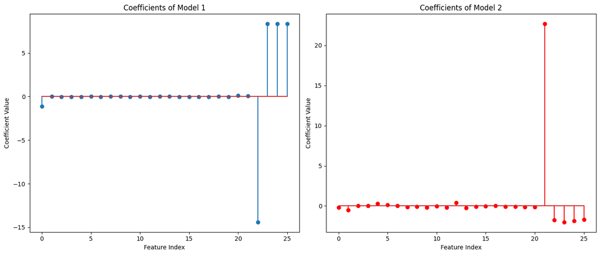

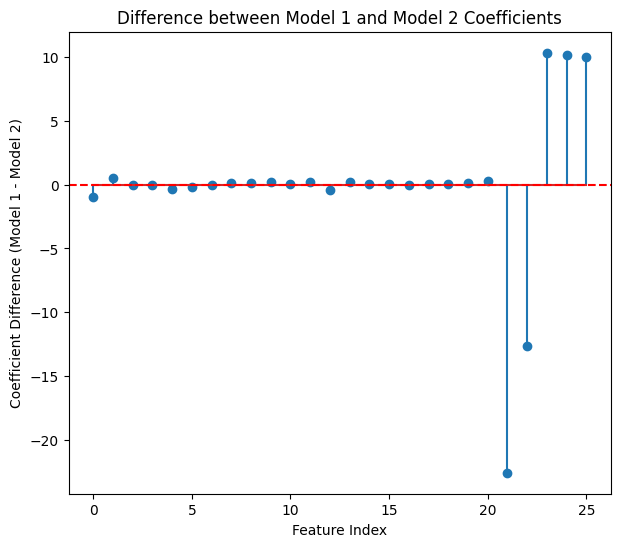

```python
import numpy as np
import matplotlib.pyplot as plt

# Coefficients from the first Logistic Regression model (Multiclass)
coefficients_model1 = np.array([
    [-1.14069320e+00,  1.46380014e-04, -8.37395727e-04, -9.26363147e-04,
     -4.42351694e-04,  2.31310889e-03, -9.32339393e-05,  6.98005509e-06,
      9.72906155e-05, -1.41990172e-04,  2.40511196e-05, -3.45858199e-04,
     -1.21930204e-05, -2.89222493e-06, -8.15770211e-05, -3.02051828e-04,
     -2.77282911e-04, -1.34849538e-04,  1.72902721e-04, -1.86039617e-04,
      1.04198632e-01,  6.29967038e-02, -1.44003018e+01,  8.34554884e+00,
      8.34528569e+00,  8.34538125e+00,  8.34614255e+00],
    [ 1.14069319e+00, -1.46380013e-04,  8.37395727e-04,  9.26363147e-04,
      4.42351694e-04, -2.31310889e-03,  9.32339393e-05, -6.98005509e-06,
     -9.72906155e-05,  1.41990172e-04, -2.40511195e-05,  3.45858199e-04,
      1.21930205e-05,  2.89222493e-06,  8.15770211e-05,  3.02051828e-04,
      2.77282911e-04,  1.34849537e-04, -1.72902721e-04,  1.86039617e-04,
     -1.04198632e-01, -6.29967038e-02,  1.44003018e+01, -8.34554884e+00,
     -8.34528568e+00, -8.34538125e+00, -8.34614255e+00]
])

# Coefficients from the second Logistic Regression model
coefficients_model2 = np.array([
    [-2.04601095e-01, -5.13916619e-01,  2.60922679e-02,  3.50335956e-02,
     3.03920630e-01,  1.50205277e-01,  3.25704323e-02, -1.19453778e-01,
    -1.05190430e-01, -1.84733802e-01, -5.43406770e-02, -2.04622594e-01,
     4.05073931e-01, -2.35399712e-01, -8.52469187e-02, -1.63073708e-02,
     3.71925669e-02, -8.47361660e-02, -6.27085587e-02, -1.46286456e-01,
    -1.61407188e-01,  2.26646122e+01, -1.74926180e+00, -2.01017019e+00,
    -1.83429120e+00, -1.68475778e+00]
])

# For visualization, we need to handle the difference in the shape of the coefficients
# Let's flatten the coefficients for comparison
coefficients_model1_flat = coefficients_model1.flatten()
coefficients_model2_flat = coefficients_model2.flatten()

# Ensure both coefficient arrays are of the same length for comparison
min_length = min(len(coefficients_model1_flat), len(coefficients_model2_flat))
coefficients_model1_flat = coefficients_model1_flat[:min_length]
coefficients_model2_flat = coefficients_model2_flat[:min_length]

# Feature indices
features = np.arange(min_length)

# Plotting the coefficients of both models
plt.figure(figsize=(14, 6))

plt.subplot(1, 2, 1)
plt.stem(features, coefficients_model1_flat)
plt.title('Coefficients of Model 1')
plt.xlabel('Feature Index')
plt.ylabel('Coefficient Value')

plt.subplot(1, 2, 2)
plt.stem(features, coefficients_model2_flat, linefmt='r-', markerfmt='ro')
plt.title('Coefficients of Model 2')
plt.xlabel('Feature Index')
plt.ylabel('Coefficient Value')

plt.tight_layout()
plt.show()

# Plotting the difference between the coefficients
coefficient_difference = coefficients_model1_flat - coefficients_model2_flat

plt.figure(figsize=(7, 6))
plt.stem(features, coefficient_difference)
plt.title('Difference between Model 1 and Model 2 Coefficients')
plt.xlabel('Feature Index')
plt.ylabel('Coefficient Difference (Model 1 - Model 2)')
plt.axhline(0, color='red', linestyle='--')
plt.show()
```

## Exceptional Work

### Option Two: Implementing BFGS from Scratch

```python
import numpy as np

def sigmoid(z):
    # Initialize the output array
    sig = np.zeros_like(z)

    # Positive indices
    pos_idx = z >= 0
    neg_idx = z < 0

    # Compute sigmoid for positive z
    sig[pos_idx] = 1 / (1 + np.exp(-z[pos_idx]))

    # Compute sigmoid for negative z to avoid overflow
    exp_z = np.exp(z[neg_idx])
    sig[neg_idx] = exp_z / (1 + exp_z)

    return sig

class LogisticRegressionBFGS:
    def __init__(self):
        self.theta = None  # Parameters

    def fit(self, X, y, max_iter=100, tol=1e-5):
        m, n = X.shape
        X = np.hstack((np.ones((m, 1)), X))  # Add intercept term
        self.theta = np.zeros(n + 1)  # Initialize parameters

        I = np.eye(n + 1)  # Identity matrix
        H = I  # Initialize Hessian approximation

        for iteration in range(max_iter):
            # Compute gradient
            h = sigmoid(X @ self.theta)
            gradient = X.T @ (h - y) / m

            # Check convergence
            if np.linalg.norm(gradient, ord=2) < tol:
                print(f"Converged in {iteration} iterations.")
                break

            # Compute search direction
            p = -H @ gradient

            # Line search to find optimal step size (using backtracking line search)
            alpha = self.line_search(X, y, self.theta, p, gradient)

            # Update parameters
            theta_new = self.theta + alpha * p

            # Update Hessian approximation
            s = theta_new - self.theta
            yk = self.gradient(X, y, theta_new) - gradient
            rho = 1.0 / (yk @ s)

            H = (I - rho * np.outer(s, yk)) @ H @ (I - rho * np.outer(yk, s)) + rho * np.outer(s, s)

            # Update theta
            self.theta = theta_new

        else:
            print(f"Did not converge within {max_iter} iterations.")

    def predict_proba(self, X):
        m = X.shape[0]
        X = np.hstack((np.ones((m, 1)), X))
        return sigmoid(X @ self.theta)

    def predict(self, X):
        return (self.predict_proba(X) >= 0.5).astype(int)

    def cost(self, X, y, theta):
        m = len(y)
        h = sigmoid(X @ theta)
        return -np.mean(y * np.log(h + 1e-15) + (1 - y) * np.log(1 - h + 1e-15))

    def gradient(self, X, y, theta):
        m = len(y)
        h = sigmoid(X @ theta)
        return X.T @ (h - y) / m

    def line_search(self, X, y, theta, p, gradient, alpha=1.0, c=1e-4, tau=0.5):
        while True:
            theta_new = theta + alpha * p
            cost_new = self.cost(X, y, theta_new)
            cost_current = self.cost(X, y, theta)
            if cost_new <= cost_current + c * alpha * gradient @ p:
                break
            alpha *= tau
        return alpha
```

```python
# Initialize and train the model
model_bfgs = LogisticRegressionBFGS()
%time model_bfgs.fit(X_train, y_train)

# Predict and evaluate accuracy
y_pred_train = model_bfgs.predict(X_train)
y_pred_test = model_bfgs.predict(X_test)

from sklearn.metrics import accuracy_score

accuracy_train = accuracy_score(y_train, y_pred_train)
accuracy_test = accuracy_score(y_test, y_pred_test)

print(f"Training Accuracy (Custom BFGS): {accuracy_train:.4f}")
print(f"Testing Accuracy (Custom BFGS): {accuracy_test:.4f}")
```

```
Converged in 51 iterations.
CPU times: user 12 s, sys: 273 ms, total: 12.3 s
Wall time: 1.33 s
Training Accuracy (Custom BFGS): 1.0000
Testing Accuracy (Custom BFGS): 1.0000
```

### SciPy's Method

```python
from scipy.optimize import minimize

class LogisticRegressionSciPy:
    def __init__(self):
        self.theta = None

    def fit(self, X, y):
        m, n = X.shape
        X = np.hstack((np.ones((m, 1)), X))  # Add intercept term

        initial_theta = np.zeros(n + 1)

        # Objective function to minimize
        def objective(theta):
            h = sigmoid(X @ theta)
            return -np.mean(y * np.log(h + 1e-15) + (1 - y) * np.log(1 - h + 1e-15))

        # Gradient of the objective function
        def grad(theta):
            h = sigmoid(X @ theta)
            return X.T @ (h - y) / m

        options = {'maxiter': 100}

        res = minimize(
            fun=objective,
            x0=initial_theta,
            method='BFGS',
            jac=grad,
            options=options
        )

        self.theta = res.x

    def predict_proba(self, X):
        m = X.shape[0]
        X = np.hstack((np.ones((m, 1)), X))
        return sigmoid(X @ self.theta)

    def predict(self, X):
        return (self.predict_proba(X) >= 0.5).astype(int)
```

```python
# Initialize and train the model
model_scipy = LogisticRegressionSciPy()
%time model_scipy.fit(X_train, y_train)

# Predict and evaluate accuracy
y_pred_train_scipy = model_scipy.predict(X_train)
y_pred_test_scipy = model_scipy.predict(X_test)

accuracy_train_scipy = accuracy_score(y_train, y_pred_train_scipy)
accuracy_test_scipy = accuracy_score(y_test, y_pred_test_scipy)

print(f"Training Accuracy (SciPy BFGS): {accuracy_train_scipy:.4f}")
print(f"Testing Accuracy (SciPy BFGS): {accuracy_test_scipy:.4f}")
```

```
CPU times: user 7.17 s, sys: 161 ms, total: 7.33 s
Wall time: 767 ms
Training Accuracy (SciPy BFGS): 1.0000
Testing Accuracy (SciPy BFGS): 1.0000
```

Conclusion? Our custom implementation is slower on this dataset than SciPy's!